# Avoidable mortality: exploratory overview

Deaths aged 0–74, preventable and treatable causes

Published

October 6, 2026

```r
library(tidyverse)
library(targets)
library(gtsummary)

theme_set(theme_minimal(base_size = 12))
pal_fill <- function(...) scale_fill_viridis_d(..., option = "D", end = 0.95)
pal_col  <- function(...) scale_colour_viridis_d(..., option = "D", end = 0.95)
```

This report describes `mort_count`, the output of `preprocess_mortality()`.

```r
tar_load(mort_count)
glimpse(mort_count)
```

```
Rows: 14,896
Columns: 14
$ causa            <chr> "C169", "I259", "I259", "C349", "I249", "I249", "C509…
$ sesso            <fct> M, M, M, M, M, M, F, F, M, M, M, F, F, M, M, M, M, M,…
$ comune_residenza <chr> "015114", "015011", "015011", "015146", "015209", "01…
$ asst             <chr> "20", "24", "24", "1", "21", "21", "25", "25", "1", "…
$ nil              <chr> NA, NA, NA, "79", NA, NA, "65", "35", "81", "28", "28…
$ distretto        <chr> "22013", "22005", "22005", "22109", "22009", "22009",…
$ eta              <int> 56, 68, 68, 65, 66, 66, 44, 62, 72, 48, 48, 73, 73, 7…
$ anno             <chr> "2023", "2023", "2023", "2024", "2023", "2023", "2022…
$ area_residenza   <chr> "015114", "015011", "015011", "015146_79", "015209", …
$ match_key        <chr> "C16", "I25", "I25", "C34", "I24", "I24", "C50", "K74…
$ group            <chr> "Cancer", "Diseases of the circulatory system", "Dise…
$ cause            <chr> "Stomach cancer", "Ischaemic heart diseases", "Ischae…
$ weight           <dbl> 1.0, 0.5, 0.5, 1.0, 0.5, 0.5, 1.0, 1.0, 1.0, 0.5, 0.5…
$ mechanism        <chr> "Lifestyle and NCDs", "Lifestyle and NCDs", "Tertiary…
```

# Univariate distributions

## Sex

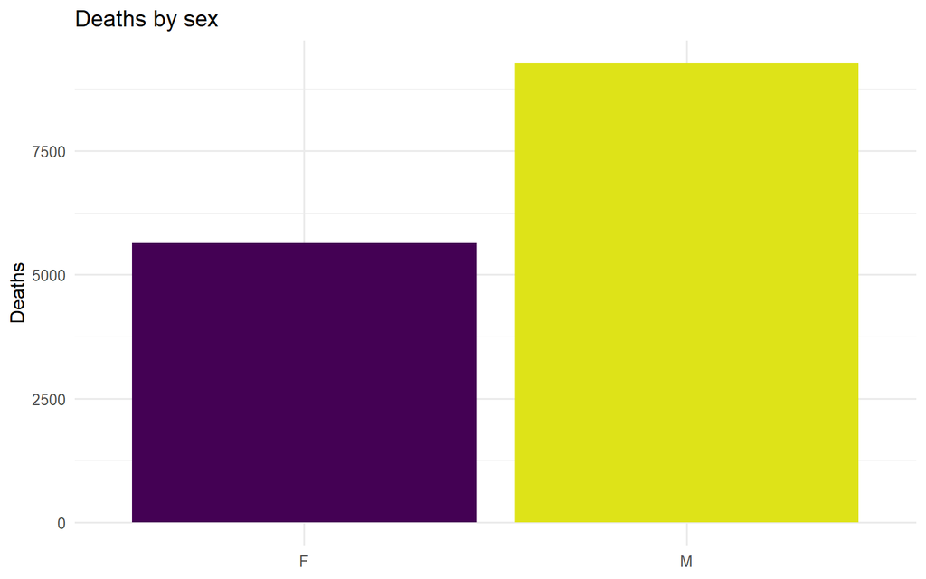

```r
ggplot(mort_count, aes(x = sesso, fill = sesso)) +
  geom_bar() +
  pal_fill(guide = "none") +
  labs(title = "Deaths by sex", x = NULL, y = "Deaths")
```

## Area of residence

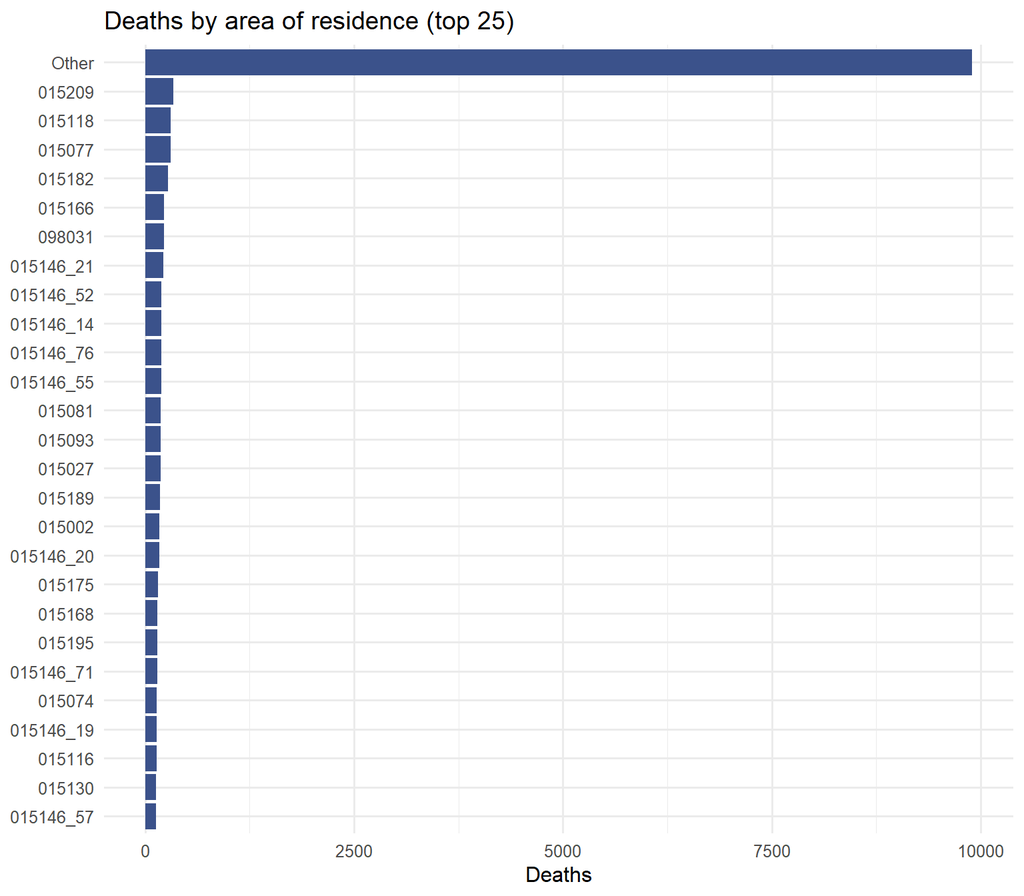

```r
mort_count |>
  mutate(area_residenza = fct_lump_n(area_residenza, n = 25)) |>
  ggplot(aes(y = fct_rev(fct_infreq(area_residenza)))) +
  geom_bar(fill = "#3b528b") +
  labs(title = "Deaths by area of residence (top 25)", x = "Deaths", y = NULL)
```

## ASST (2022-2024)

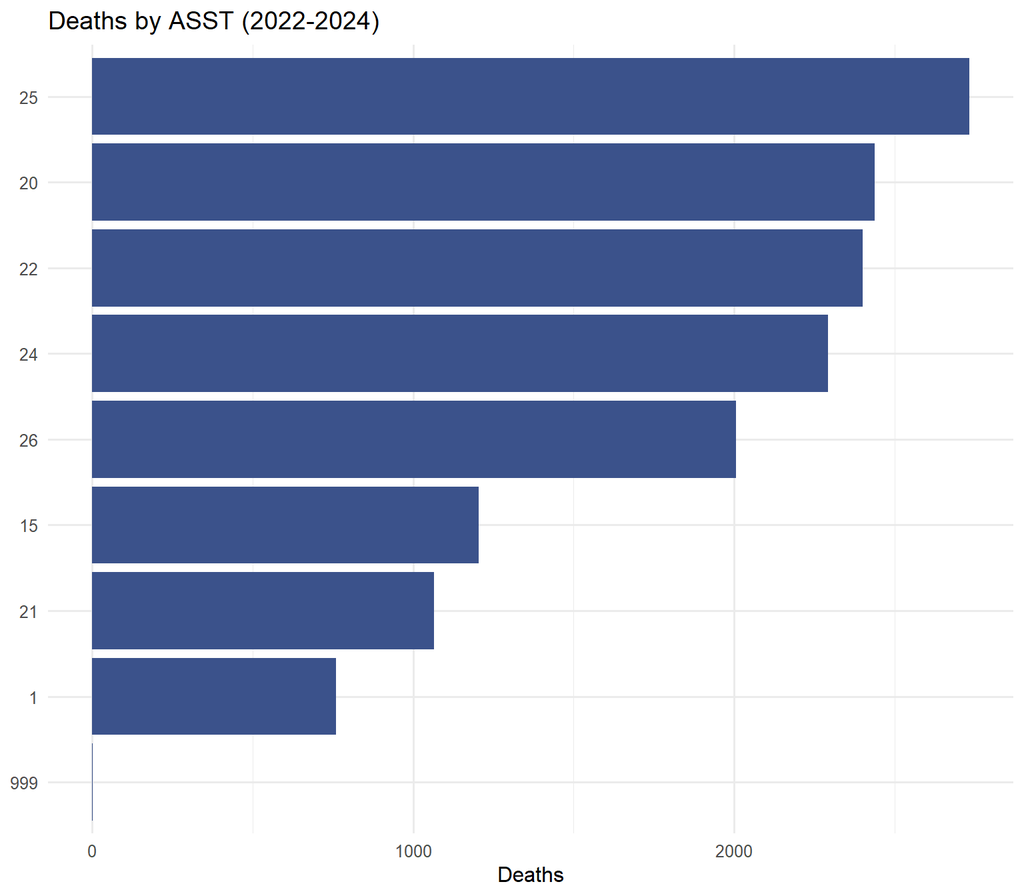

```r
ggplot(mort_count, aes(y = fct_rev(fct_infreq(asst)))) +
  geom_bar(fill = "#3b528b") +
  labs(title = "Deaths by ASST (2022-2024)", x = "Deaths", y = NULL)
```

## Age at death

Note that the population is restricted to premature deaths (under 75), so the distribution is bounded at 74.

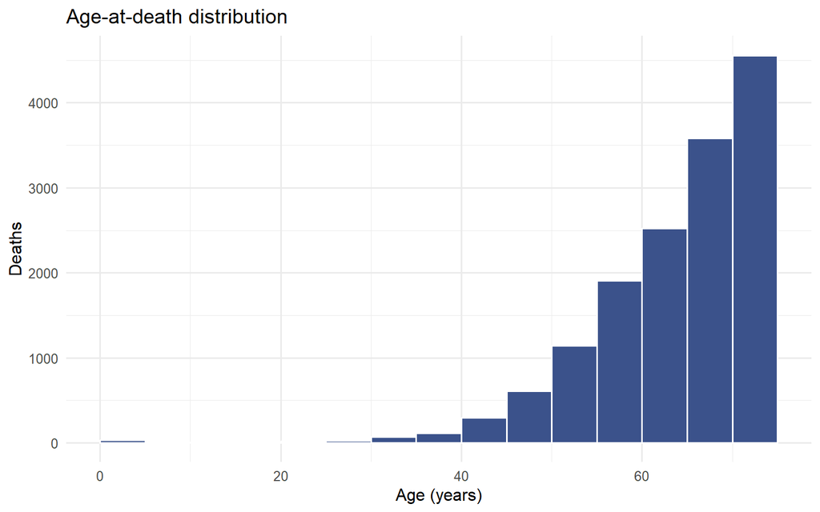

```r
ggplot(mort_count, aes(x = eta)) +
  geom_histogram(binwidth = 5, boundary = 0,
                 fill = "#3b528b", colour = "white") +
  labs(title = "Age-at-death distribution", x = "Age (years)", y = "Deaths")
```

## Cause group

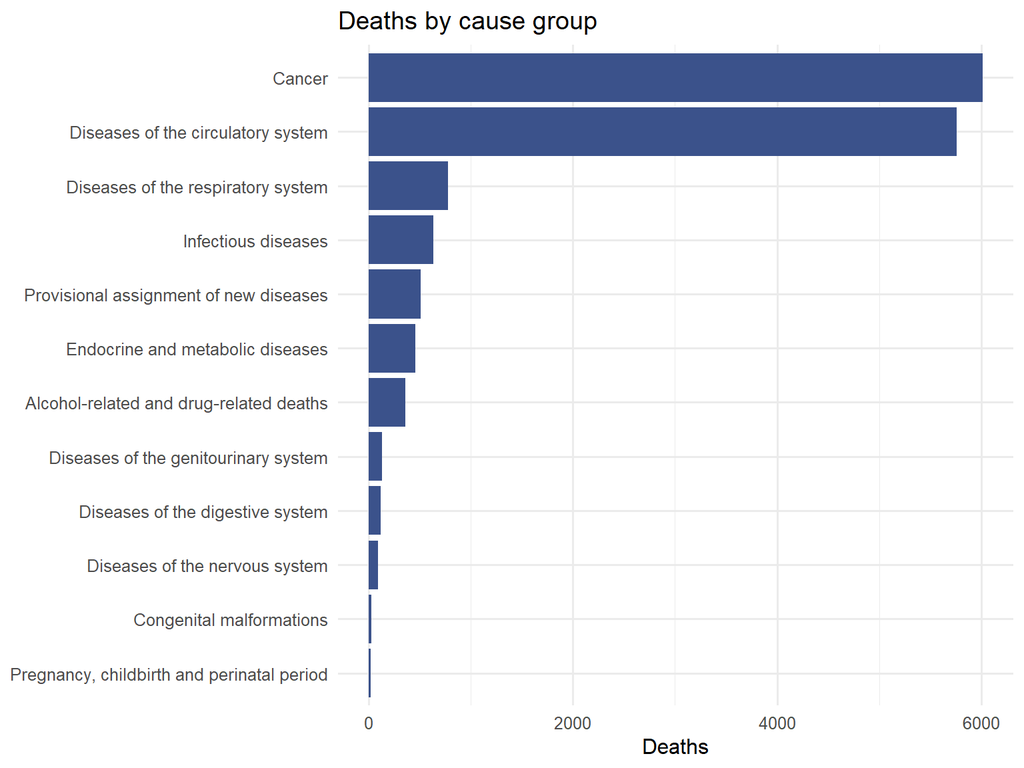

```r
ggplot(mort_count, aes(y = fct_rev(fct_infreq(group)))) +
  geom_bar(fill = "#3b528b") +
  labs(title = "Deaths by cause group", x = "Deaths", y = NULL)
```

## Mechanism

`mechanism` records the avoidability lever each death is attributed to (the preventable mechanisms together with the treatable arms).

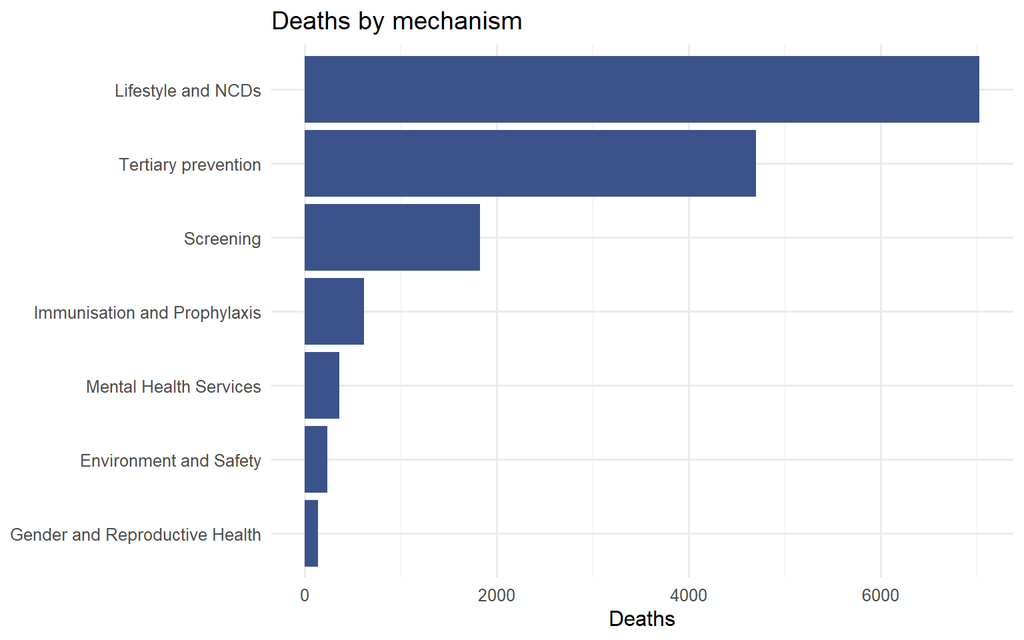

```r
ggplot(mort_count, aes(y = fct_rev(fct_infreq(mechanism)))) +
  geom_bar(fill = "#3b528b") +
  labs(title = "Deaths by mechanism", x = "Deaths", y = NULL)
```

## Cause

There are many individual causes, so the 20 most frequent are shown and the remainder collapsed into “Other”.

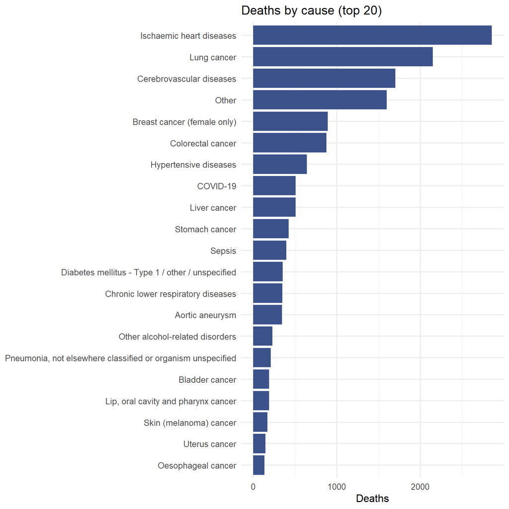

```r
mort_count |>
  mutate(cause = fct_lump_n(cause, n = 20)) |>
  ggplot(aes(y = fct_rev(fct_infreq(cause)))) +
  geom_bar(fill = "#3b528b") +
  labs(title = "Deaths by cause (top 20)", x = "Deaths", y = NULL)
```

## Summary table

A Table 1 summarising the categorical variables of interest across all deaths. Counts and column percentages are shown for each level.

```r
mort_count |>
  select(sesso, asst, group, cause, mechanism) |>
  mutate(cause = fct_lump_n(cause, 15)) |>
  tbl_summary(
    label = list(
      sesso     ~ "Sex",
      asst ~ "ASST (2022-2024)",
      group     ~ "Cause group",
      cause     ~ "Cause",
      mechanism ~ "Mechanism"
    )
  ) |>
  bold_labels()
```

| **Characteristic** | **N = 14,896**<sup>1</sup> |
| --- | --- |
| Sex |  |
| F | 5,637 (38%) |
| M | 9,259 (62%) |
| ASST (2022-2024) |  |
| 1 | 761 (5.1%) |
| 15 | 1,204 (8.1%) |
| 20 | 2,436 (16%) |
| 21 | 1,065 (7.1%) |
| 22 | 2,399 (16%) |
| 24 | 2,292 (15%) |
| 25 | 2,731 (18%) |
| 26 | 2,006 (13%) |
| 999 | 2 (<0.1%) |
| Cause group |  |
| Alcohol-related and drug-related deaths | 360 (2.4%) |
| Cancer | 6,009 (40%) |
| Congenital malformations | 26 (0.2%) |
| Diseases of the circulatory system | 5,759 (39%) |
| Diseases of the digestive system | 119 (0.8%) |
| Diseases of the genitourinary system | 132 (0.9%) |
| Diseases of the nervous system | 91 (0.6%) |
| Diseases of the respiratory system | 776 (5.2%) |
| Endocrine and metabolic diseases | 459 (3.1%) |
| Infectious diseases | 635 (4.3%) |
| Pregnancy, childbirth and perinatal period | 22 (0.1%) |
| Provisional assignment of new diseases | 508 (3.4%) |
| Cause |  |
| Aortic aneurysm | 348 (2.3%) |
| Breast cancer (female only) | 893 (6.0%) |
| Cerebrovascular diseases | 1,702 (11%) |
| Chronic lower respiratory diseases | 350 (2.3%) |
| Colorectal cancer | 879 (5.9%) |
| COVID-19 | 508 (3.4%) |
| Diabetes mellitus - Type 1 / other / unspecified | 355 (2.4%) |
| Hypertensive diseases | 642 (4.3%) |
| Ischaemic heart diseases | 2,856 (19%) |
| Liver cancer | 507 (3.4%) |
| Lung cancer | 2,151 (14%) |
| Other alcohol-related disorders | 232 (1.6%) |
| Pneumonia, not elsewhere classified or organism unspecified | 212 (1.4%) |
| Sepsis | 399 (2.7%) |
| Stomach cancer | 424 (2.8%) |
| Other | 2,438 (16%) |
| Mechanism |  |
| Environment and Safety | 234 (1.6%) |
| Gender and Reproductive Health | 133 (0.9%) |
| Immunisation and Prophylaxis | 618 (4.1%) |
| Lifestyle and NCDs | 7,029 (47%) |
| Mental Health Services | 360 (2.4%) |
| Screening | 1,822 (12%) |
| Tertiary prevention | 4,700 (32%) |

<sup>1</sup> n (%)

# Bivariate distributions

## Cause-group composition within each ASST

Each bar is filled to 100%, so it shows the *share* of deaths attributable to each cause group within an ASST, making the mix comparable across areas of different size.

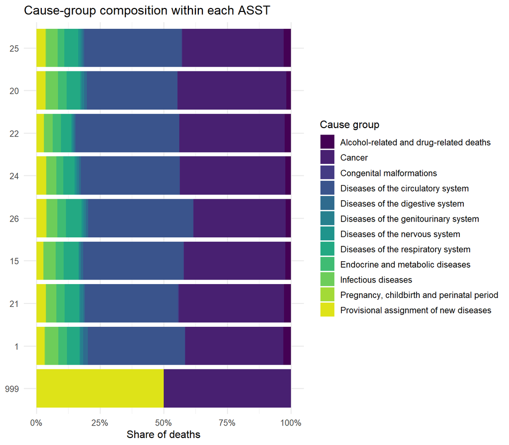

```r
ggplot(mort_count, aes(y = fct_rev(fct_infreq(asst)), fill = group)) +
  geom_bar(position = "fill") +
  scale_x_continuous(labels = scales::percent) +
  pal_fill() +
  labs(title = "Cause-group composition within each ASST",
       x = "Share of deaths", y = NULL, fill = "Cause group")
```

## Age pattern of mortality by cause group

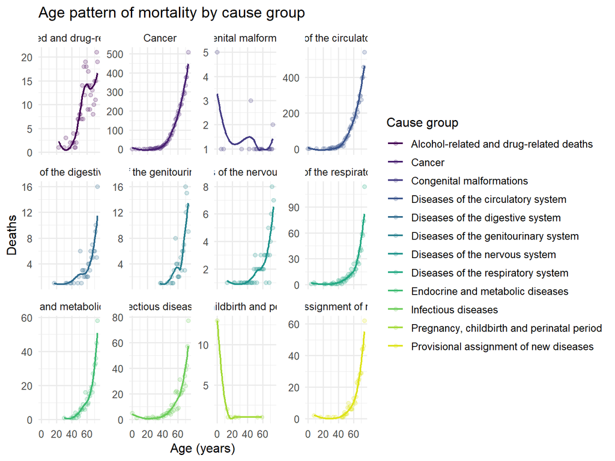

```r
age_group <- mort_count |>
  count(group, eta, name = "deaths")

ggplot(age_group, aes(x = eta, y = deaths, colour = group)) +
  geom_point(alpha = 0.2) +
  geom_smooth(se = FALSE, linewidth = 0.8) +
  facet_wrap(~ group, scales = "free_y") +
  pal_col() +
  labs(title = "Age pattern of mortality by cause group",
       x = "Age (years)", y = "Deaths", colour = "Cause group")
```

## Mechanism by cause group

How the avoidability mechanisms map onto cause groups. Each bar is a cause group, stacked by the count of deaths in each mechanism, so the plot shows both which groups carry the most deaths and the mix of mechanisms within each. (A given cause group can span more than one mechanism — e.g. the 50/50 split causes.)

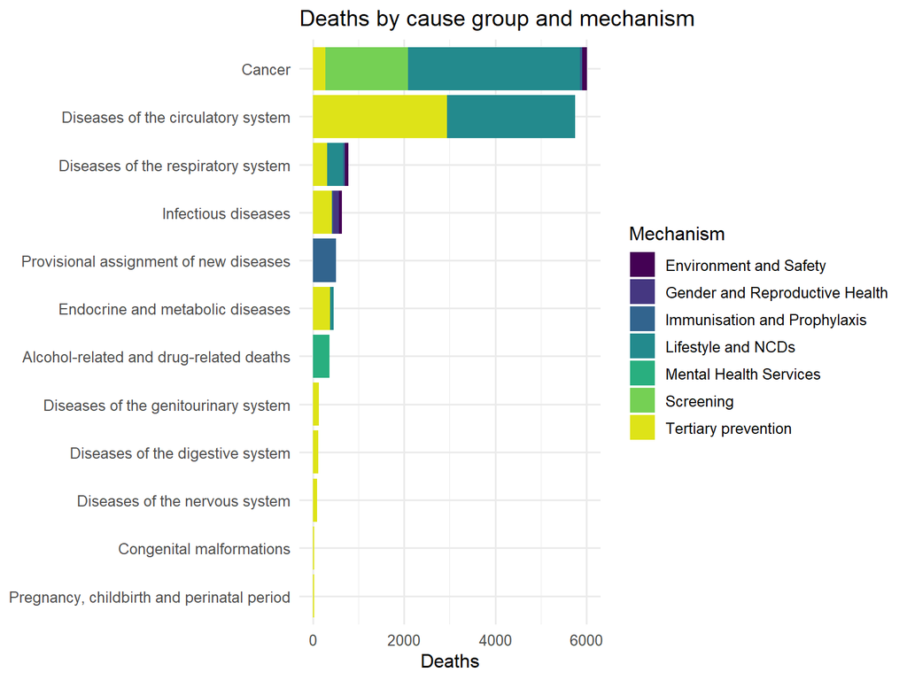

```r
ggplot(mort_count, aes(y = fct_rev(fct_infreq(group)), fill = mechanism)) +
  geom_bar() +
  pal_fill() +
  labs(title = "Deaths by cause group and mechanism",
       x = "Deaths", y = NULL, fill = "Mechanism")
```

# MAPS

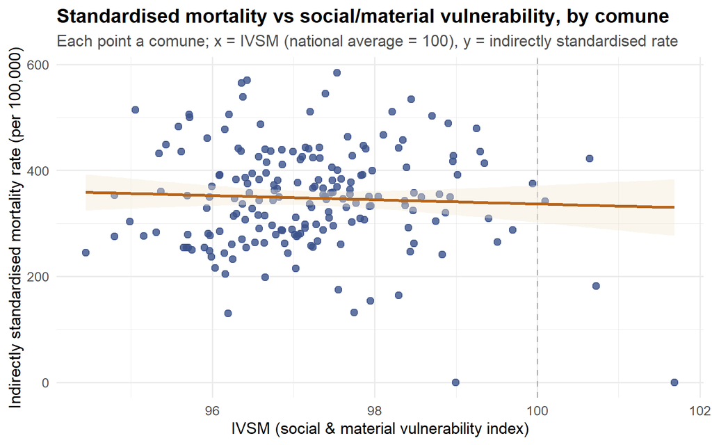

```r
tar_read(scatter_smr_ivsm)
```

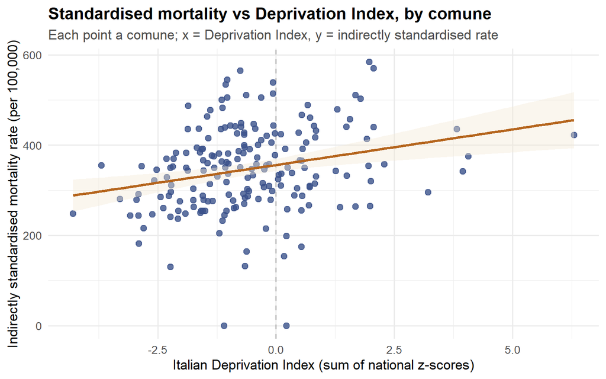

```r
tar_read(scatter_smr_di)
```

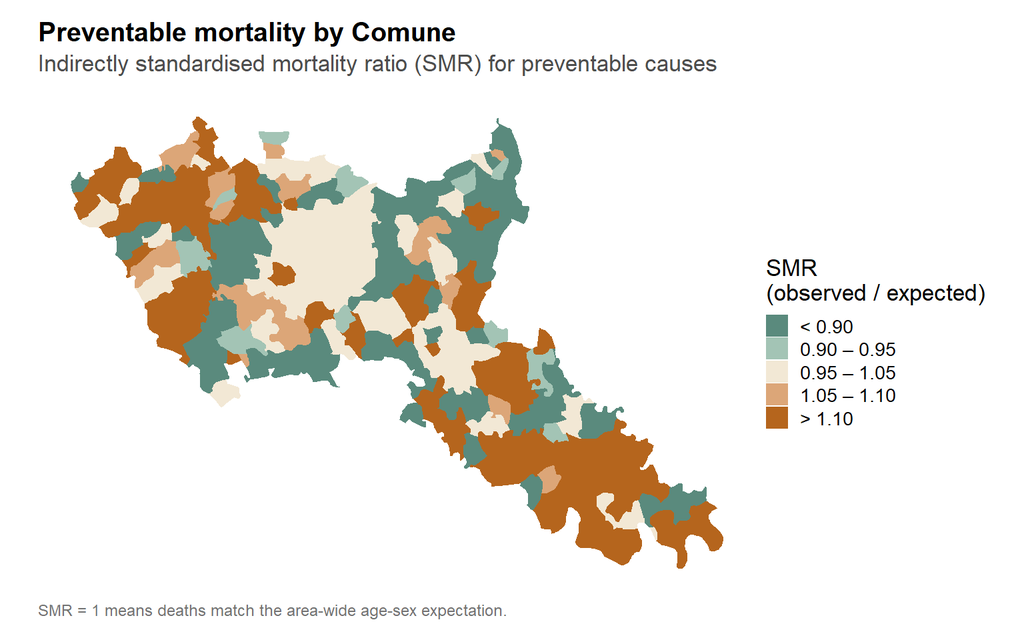

```r
tar_read(map_smr_overall)
```

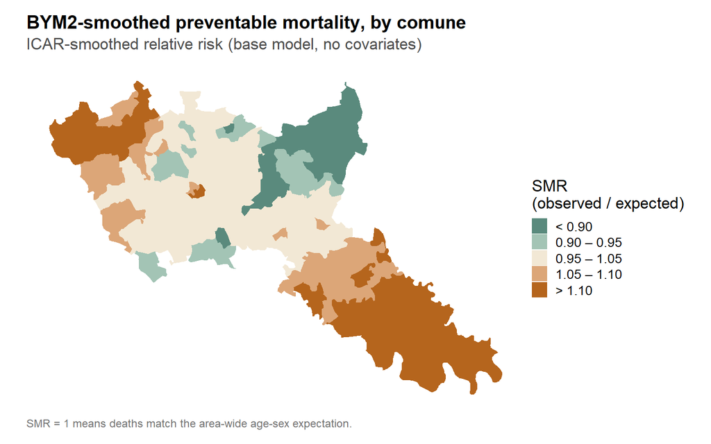

```r
tar_read(map_smr_bym2)
```

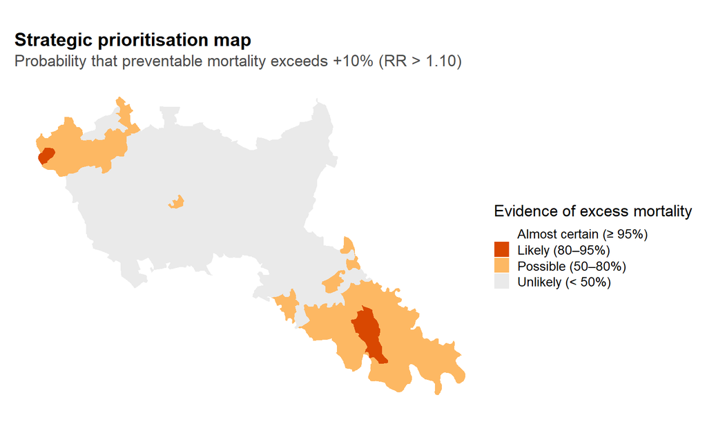

```r
tar_read(map_exceedance)
```

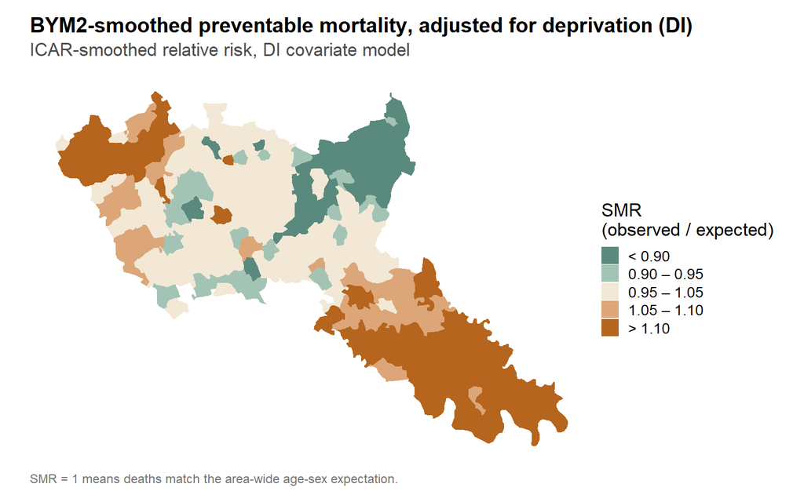

```r
tar_read(map_smr_di)
```

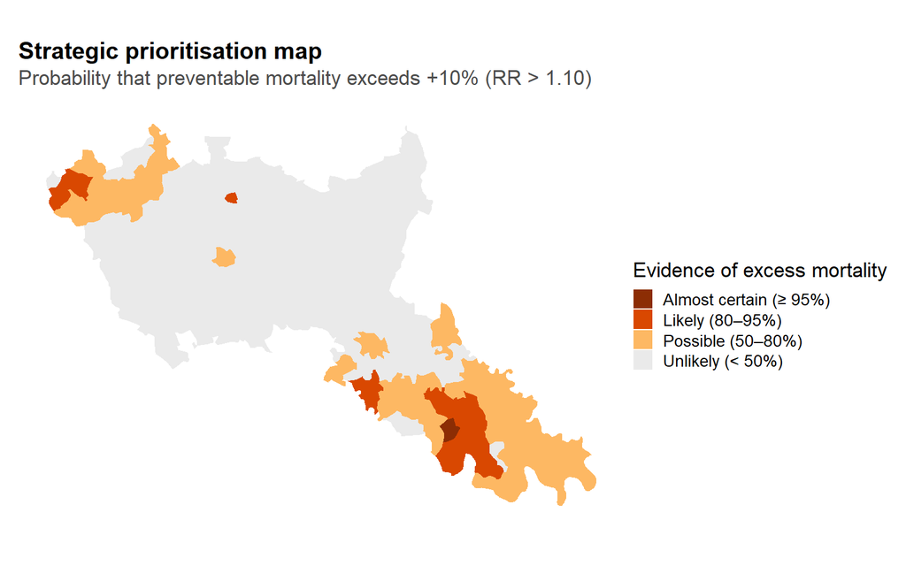

```r
tar_read(map_exceedance_di)
```

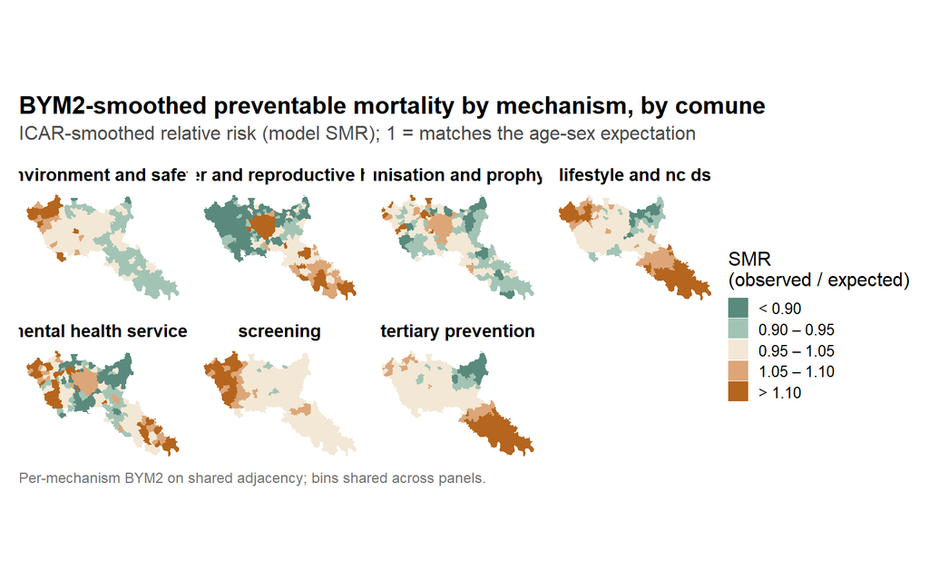

```r
tar_read(map_smr_facets_bym2)
```

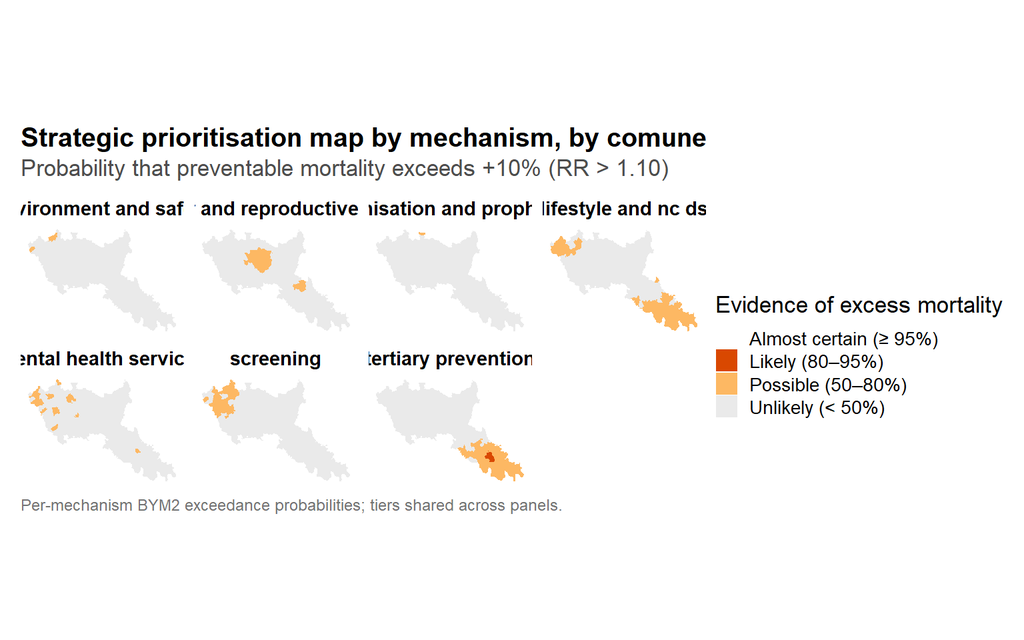

```r
tar_read(map_exceedance_facets_bym2)
```